# Vamos começar

# Introdução

A linguagem R é usada para análise e manipulação de dados. Você verá que o conhecimento que será adquirido no curso será escalável, o que ajudará a utilizar outros conceitos em R de forma semelhante com o ensinado.

> Dica de links:  
> [R-bloggers](http://www.r-bloggers.com)  
> [RPubs](https://rpubs.com)  
> [Stack Overflow](http://stackoverflow.com)

## Programação Aula 1

- Explorando RStudio, RStudio Cloud
- Instalando e Carregando Pacotes
- Operadores matemáticos, relacionais e lógicos
- Definindo Variáveis
- Objetos em R

# Parte 1

## Explorando RStudio

RStudio é um software livre de ambiente de desenvolvimento integrado para R.

```
# Adição
1+1
```

```
# Multiplicação
14 * 11
```

```
1:100
```

- O **R** não irá rodar nada após o caracter `#`, então ele é muito usado para escrever comentários no código;

## Conhecendo RStudio Cloud

[RStudio Cloud](https://rstudio.cloud/) é o RStudio hospenado na nuvem e pode ser aberto em qualquer navegador de internet.

[figure not shown]

## Instalando pacotes

O R possui uma grande comunidade que desenvolve novos pacotes com novas funções para oferecer as mais diversas soluções para vários tipos de análises. Normalmente os pacotes ficam hospedados no repositório [CRAN](https://cran.r-project.org/).

[figure not shown]

[figure not shown]

Objetivo de análise

```
install.packages("tidyverse")
install.packages("dplyr")
install.packages("devtools")
```

## Carregando pacotes

```
library(tidyverse)
```

## Ajuda!

```
?sqrt
?log10
help(sample)
```

Se uma função vem de um pacote, o **R** não será capaz de encontrar sua página de ajuda a menos que o pacote seja lido.

Outras formas de pedir ajuda:  
- Postar uma pergunta na [Comunidade R](https://community.rstudio.com/);  
- Procurar a dúvida no [StackOverflow](https://stackoverflow.com/questions/tagged/r) ou postar uma nova dúvida.  
- Procurar o erro ou a dúvida no Google, lembrando que se procurá-la em inglês a chance de achar uma resposta é maior.

## Operações Matemáticas

Nome

Operador

Exemplo

Resultado

Adição

1+1

2

Subtração

2-1

1

Multiplicação

2*2

4

Divisão

/

4/2

2

Potência

^ ou **

3^2

9

Resto da divisão

%%

9%%2

1

Parte inteira da divisão

%/%

9%/%2

4

Essa expressão matemática:
$$(7^2)*10 + \frac{30}{2}$$

Ficaria assim `(7^2)*10 +30/2`

### Algumas Funções Matemáticas

| Fun | Significado |
| --- | --- |
| log(x) | Log de x na base e |
| exp(x) | Exponencial e^x |
| log(x,n) | Log de x na base n |
| log10(x) | Log de x na base 10 |
| sqrt(x) | Raiz Quadrada |
| cos(x), sin(x), tan(x) | Funções trigonométricas |
| acos(x), asin(x), atan(x) | Funções trigonométricas inversas |
| abs(x) | valor absoluto |
| pi | número 3.141593… |

## Operadores Relacionais

| Operador | Significado | Teste | Resultado |
| --- | --- | --- | --- |
| < | menor que | 3<1 | FALSE |
| <= | menor ou igual que | 3<=3 | TRUE |
| > | maior que | 3>1 | TRUE |
| >= | maior ou igual que | 1>=1 | TRUE |
| == | igual a | 5==5 | TRUE |
| != | diferente de | 5!=5 | FALSE |
| %in% | está contido em | 3 %in% 1:3 | TRUE |

## Operadores Lógicos

```r
data.frame(Operador = c("!", "&", "or ou |"),
       Significado = c("Negativa de", "e", "ou"),
       Teste = c("!TRUE", "TRUE&FALSE", "TRUE|FALSE"),
       Resultado = c(!TRUE, TRUE&FALSE, TRUE|FALSE)) %>% kable() %>% kable_styling()
```

| Operador | Significado | Teste | Resultado |
| --- | --- | --- | --- |
| ! | Negativa de | !TRUE | FALSE |
| & | e | TRUE&FALSE | FALSE |
| or ou \| | ou | TRUE\|FALSE | TRUE |

# Parte 2

## Objetos

Os objetos servem para guardar os dados momentaneamente na memória do computador para que eles possam ser usados posteriormente.

```
a <-1
a
a+2
```

Para criar um objeto, escolha um nome e então use o símbolo `<-` ou `=` para salvar o dado dentro. O **R** tem algumas regras para escolha do nome.  
- O nome não pode começar com um número;  
- O nome não pode usar alguns símbolos especiais como como `^,!,$,@,+,-,/ ou *`;

| Nomes Bons | Nomes que causam erros |
| --- | --- |
| a | 1trial |
| b | $ |
| FOO | ^mean |
| my_var | 2nd |
| .day | !bad |

Você pode ver quais nomes de objetos já foram usados com a função `ls`:

```
ls()
```

## Tipo de Dados

Os dados aparecerão com formas diferentes e serão usados de formas diferentes.

### Numeric

Em geral, R irá salvar qualquer número no tipo double (como números decimais). Normalmente você sabe com qual tipo de objeto está trabalhando no R, mas você pode também perguntar ao R qual tipo de objeto é com `typeof`.

```
typeof(a)
is.double(a) #Pergunta se é do tipo Double
```

### Integer

Para transfomá-lo para inteiro é só colocar um L depois do número. Os números criados como sequência, por exemplo, `1:20`, também são Integer.

```
b = 9L
typeof(b)
is.integer(1:9)
```

### Character

Os dados tipo `character` são dados de texto. Dessa forma, esse tipo de dado não pode ser usado em operações aritméticas.

```
char1 = 'A'
char1
typeof(char1)
```

### Complex

São dados tipo números complexos

```
# Complex
compl = 2.5 + 5i
compl
typeof(compl)
```

### Logic

Os dados Logic são do tipo TRUE ou FALSE

```
# Logic
x = 1; y = 2
z = x > y
z
```

## Tipo de Objetos

### Vetor

Vários valores do mesmo tipo em um objeto. Caracterizado por só ter uma dimensão É criado agrupando os valores com `c`:

```
vetorA = c(1,54,8,6,4,6)
vetorA
is.vector(vetorA)
length(vetorA)
```

É possível fazer vetores com cada tipo de dado existente

```
# Vetor de strings
vetor_caracter = c("Linguagem", "R", "UFG")
vetor_caracter


# Vetor numérico
vetor_numerico = c(1.90, 45.3, 300.5)
vetor_numerico

# Vetor de valores lógicos
vetor_logico = c(TRUE, FALSE, TRUE, TRUE, TRUE, FALSE, FALSE)
vetor_logico

# Vetor de números inteiros
vetor_integer  = c(2L, 4L, 6L)
vetor_integer

# seq()
vetor_SEQ = seq(1:10)
vetor_SEQ

# rep()
vetor_REP = rep(1:5)
vetor_REP



# Combinando vetores
v1 = c(2, 3, 5)
v2 = c("aa", "bb", "cc", "dd", "ee")
c(v1, v2)


# Operações com Vetores
x = c(7, 1, 2, 5, 6)
y = c(4, 7, 3, 6, 9)

x * 5
x + y

# Somando vetores com números diferentes de elementos
a = c(9, 10,  2, 20,  7)
b = c(16,  5, 11, 13,  2, 14, 17, 10,  4, 12)
a + b


# Vetor Nomeado
v = c("Universidade Federal de Goiás", "UFG")
v
names(v) = c("Universidade", "Sigla")
v
v["Universidade"]
```

### Matriz

Vários valores do mesmo tipo em um objeto. Caracterizado por só ter duas dimensão. É criado usando a função `matrix(data , nrow , ncol , byrow , dimnames )`:

```
matrix(1:10, nrow = 2)
#Definindo o número de linhas
matrix(c(1,2,3,4,5,7), nrow = 6)
#Definindo o número de colunas
matrix(c( 1,2,3,4,5,7), ncol = 2, byrow = T, dimnames = list(c("Linha 1", "Linha 2", "Linha 3" ), c( "Coluna 1", " Coluna 2") ))

# Selecionando partes da matrix

mat <- matrix(c(2,3,4,4,5,9), nr = 2)
mat
mat[1,2]
mat[2,2]
mat[1,3]
mat[,2]
```

```
# Criando uma matriz diagonal
matriz = 1:3
diag(matriz)

# Transposta da matriz
W <- matrix (c(2,4,8,12 ), nr = 2, ncol = 2)
W
t(W)
U <- t(W)
U

# Obtendo uma matriz inversa
solve(W)

# Multiplicação de Matrizes
mat1 <- matrix(c(2,3,4,5), nr = 2)
mat1
mat2 <- matrix(c(6,7,8,9), nr = 2)
mat2
mat1 * mat2
mat1 %*% mat2 # multiplicação matricial

# Combinando Matrizes
mat4 <- matrix(c(2,3,4,5), nr = 2)
mat4
mat5 <- matrix(c(6,7,8,9), nr = 2)
mat5
cbind(mat4, mat5)
rbind(mat4, mat5)


# Desconstruindo a Matriz
c(mat4)
```

### Data Frames

Data Frames: dados de diferentes tipos. Maneira mais fácil de explicar data frames: é uma matriz com diferentes tipos de dados. Você pode pensar em um data.frame do R como sendo o mais próximo de uma planilha do Excel porque armazena dados de forma semelhante.

```
View(iris)
length(iris)
```

```
df <- data.frame(face = c("ace", "two", "six"),
  suit = c("clubs", "clubs", "clubs"), value = c(1, 2, 3))
df
```

### Listas

Listas: coleção de diferentes objetos. Diferentes tipos de dados são possíveis e comuns

```
list1 <- list(100:130, "R", list(TRUE, FALSE))
list1

list1[1]
list1[[1]]
list1[[1]][1]
```

```
a = rnorm(400)
teste = shapiro.test(a)
teste

typeof(teste)

teste$statistic

teste[2]
```

## Seleção de elementos

```
vetor = 1:10

matriz = matrix(10:25, nrow = 4)

dataframe = data.frame(Numeros = seq(1,10,0.5),
                       Letras = letters[1:19])

lista = list(vetor, matriz, dataframe)
```

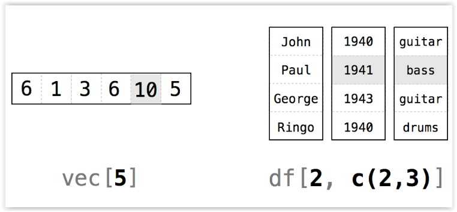

Seleção

### Inteiros Positivos

```
# Indexação de vetores
vetor[6]

# Indexação de matriz

matriz[c(1:3), c(3,4)]

# Indexação de dataframe

dataframe[c(1:5)*2,1]
```

### Inteiros Negativos

```
# Indexação de vetores
vetor[-6]

# Indexação de matriz

matriz[-c(1:3), c(3,4)]

# Indexação de dataframe

dataframe[-(c(1:5)*2),1]
```

### Espaço em Branco

```
# Indexação de matriz

matriz[, c(3,4)]

# Indexação de dataframe

dataframe[2:4,]
```

### Valores lógicos

```
# Indexação de vetor
vetor[vetor > 5]

# Indexação de matrix

matriz[matriz[,1] == 10, ]

# Indexação de dataframe
dataframe[, ]
```

### Nomes

```
dataframe$Letras
dataframe$Letras[2]
```

# Exercícios

## Vetor

- Crie um vetor de 2 a 10
- Verifique se é um vetor
- Verifique que tipo de dados foram armazenados no vetor

Érika S. Machado